# PRJEB13583 P. trichocarpa alignments Control samples Biological QA

Vikash Kumar & Nicolas Delhomme

2017-10-17

# 1 Setup

Set the working dir

```r
setwd("/mnt/picea/projects/aspseq/facility/PRJEB13583/Potri03")
```

Load libraries

```r
suppressPackageStartupMessages(library(DESeq2))
suppressPackageStartupMessages(library(gplots))
suppressPackageStartupMessages(library(LSD))
suppressPackageStartupMessages(library(parallel))
suppressPackageStartupMessages(library(pander))
suppressPackageStartupMessages(library(RColorBrewer))
suppressPackageStartupMessages(library(scatterplot3d))
suppressPackageStartupMessages(library(vsn))
```

Source some helper functions

```r
source("~/Git/UPSCb/src/R/plot.multidensity.R")
suppressMessages(source("~/Git/UPSCb/src/R/densityPlot.R"))
suppressMessages(source("~/Git/UPSCb/src/R/plotMA.R"))
suppressMessages(source("~/Git/UPSCb/src/R/volcanoPlot.R"))
suppressMessages(source("~/Git/UPSCb/src/R/featureSelection.R"))
```

Create palettes

```r
pal <- brewer.pal(8,"Dark2")
hpal <- colorRampPalette(c("blue","white","red"))(100)
```

Register the default plot margin

```r
mar <- par("mar")
```

# 2 Raw data

## 2.1 Load the data

Read the sample information

```r
samples <- read.csv("~/Git/UPSCb/projects/facility-immanen-et-al/doc/PRJEB13583-Ctl-bestaligned frc.csv")
samples$othernames <- sprintf("AF%02d",as.integer(sub("AF","",samples$othernames)))
ord <- order(samples$Tree,samples$othernames)
samples <- samples[ord,]
```

Read the HTSeq results

```r
res <- mclapply(dir("htseq",pattern="*.txt",full.names=TRUE),function(fil){
  read.delim(fil,header=FALSE,stringsAsFactors=FALSE)
},mc.cores=max(mcaffinity()))
```

Rename them

```r
names(res) <- sub("_sortmerna.*\\.txt","",dir("htseq",pattern="*.txt"))
```

Select the one we need

```r
res <- res[names(res) %in% samples$SampleID]
```

Re order the data

```r
res <- res[match(samples$SampleID,names(res))]
#samples <- samples[match(names(res),samples$SampleID),]
```

Extract the count table

```r
addInfo <- c("__no_feature","__ambiguous","__too_low_aQual","__not_aligned","__alignment_not_unique")
sel <- match(addInfo,res[[1]][,1])
count.table <- do.call(cbind,lapply(res,"[",2))[-sel,]
colnames(count.table) <- names(res)
rownames(count.table) <- res[[1]][,1][-sel]
dir.create(file.path("analysis","HTSeq"),recursive = TRUE, showWarnings = FALSE)
write.csv(count.table,"analysis/HTSeq/raw-unormalised-data_ctrl-selected frc.csv")
```

Extract the HTSeq stats

```r
count.stats <- do.call(cbind,lapply(res,"[",2))[sel,]
colnames(count.stats) <- names(res)
rownames(count.stats) <- sub("__","",addInfo)
count.stats <- rbind(count.stats,aligned=colSums(count.table))
count.stats <- count.stats[rowSums(count.stats) > 0,]
pander(apply(count.stats,2,function(co){round(co*100/sum(co))}))
```

Table continues below

|  | ERR1361084 | ERR1361085 | ERR1361086 | ERR1361087 |
| --- | --- | --- | --- | --- |
| **no_feature** | 12 | 9 | 8 | 7 |
| **ambiguous** | 1 | 1 | 1 | 1 |
| **alignment_not_unique** | 24 | 20 | 17 | 15 |
| **aligned** | 63 | 71 | 74 | 77 |

Table continues below

|  | ERR1361088 | ERR1361089 | ERR1361090 | ERR1361091 |
| --- | --- | --- | --- | --- |
| **no_feature** | 5 | 6 | 6 | 5 |
| **ambiguous** | 1 | 1 | 1 | 1 |
| **alignment_not_unique** | 14 | 14 | 14 | 14 |
| **aligned** | 80 | 79 | 79 | 80 |

Table continues below

|  | ERR1361095 | ERR1361098 | ERR1361099 | ERR1361100 |
| --- | --- | --- | --- | --- |
| **no_feature** | 5 | 6 | 6 | 5 |
| **ambiguous** | 2 | 1 | 1 | 1 |
| **alignment_not_unique** | 17 | 16 | 21 | 16 |
| **aligned** | 76 | 77 | 73 | 78 |

Table continues below

|  | ERR1361101 | ERR1361102 | ERR1361103 | ERR1361104 |
| --- | --- | --- | --- | --- |
| **no_feature** | 5 | 5 | 5 | 5 |
| **ambiguous** | 1 | 1 | 1 | 1 |
| **alignment_not_unique** | 16 | 18 | 15 | 15 |
| **aligned** | 78 | 77 | 79 | 80 |

Table continues below

|  | ERR1361105 | ERR1361106 | ERR1361107 | ERR1361108 |
| --- | --- | --- | --- | --- |
| **no_feature** | 5 | 5 | 4 | 3 |
| **ambiguous** | 1 | 1 | 1 | 1 |
| **alignment_not_unique** | 14 | 14 | 13 | 13 |
| **aligned** | 81 | 81 | 83 | 83 |

Table continues below

|  | ERR1361109 | ERR1361129 | ERR1361130 | ERR1361131 |
| --- | --- | --- | --- | --- |
| **no_feature** | 3 | 6 | 6 | 6 |
| **ambiguous** | 1 | 1 | 1 | 1 |
| **alignment_not_unique** | 14 | 16 | 18 | 19 |
| **aligned** | 82 | 77 | 75 | 75 |

Table continues below

|  | ERR1361114 | ERR1361115 | ERR1361116 | ERR1361117 |
| --- | --- | --- | --- | --- |
| **no_feature** | 5 | 6 | 5 | 4 |
| **ambiguous** | 1 | 0 | 0 | 1 |
| **alignment_not_unique** | 18 | 21 | 17 | 15 |
| **aligned** | 76 | 73 | 77 | 80 |

Table continues below

|  | ERR1361118 | ERR1361119 | ERR1361120 | ERR1361121 |
| --- | --- | --- | --- | --- |
| **no_feature** | 4 | 4 | 4 | 4 |
| **ambiguous** | 1 | 1 | 1 | 1 |
| **alignment_not_unique** | 15 | 15 | 16 | 16 |
| **aligned** | 81 | 80 | 80 | 79 |

|  | ERR1361122 |
| --- | --- |
| **no_feature** | 4 |
| **ambiguous** | 1 |
| **alignment_not_unique** | 17 |
| **aligned** | 78 |

```r
col <- pal[1:nrow(count.stats)]
```

## 2.2 Raw QC

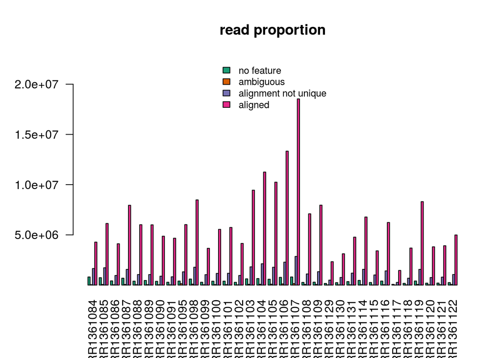

```r
par(mar=c(5.1,5.1,4.1,2.1))
barplot(as.matrix(count.stats),col=col,beside=TRUE,las=2,main="read proportion",
ylim=range(count.stats) + c(0,4e+6))
legend("top",fill=col,legend=gsub("_"," ",rownames(count.stats)),bty="n",cex=0.8)
```

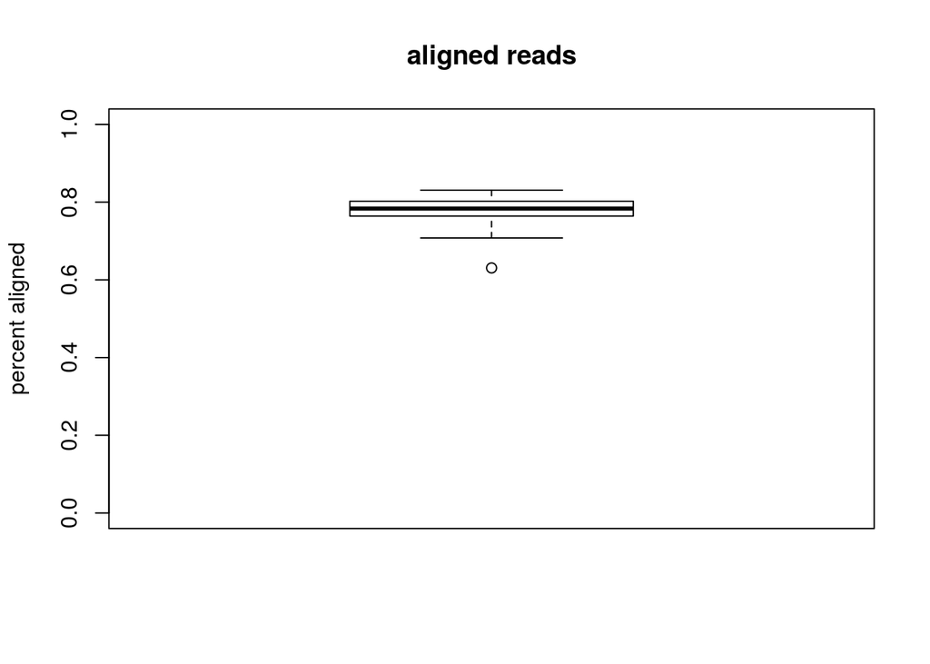

```r
par(mar=mar)
boxplot(unlist(count.stats["aligned",]/colSums(count.stats)),
main="aligned reads",ylab="percent aligned",ylim=c(0,1))
```

```r
sel <- rowSums(count.table) == 0

sprintf("%s%% percent (%s) of %s genes are not expressed",
round(sum(sel) * 100/ nrow(count.table),digits=1),
sum(sel),
nrow(count.table))
```

```
## [1] "13% percent (5373) of 41335 genes are not expressed"
```

plot the mean expression density

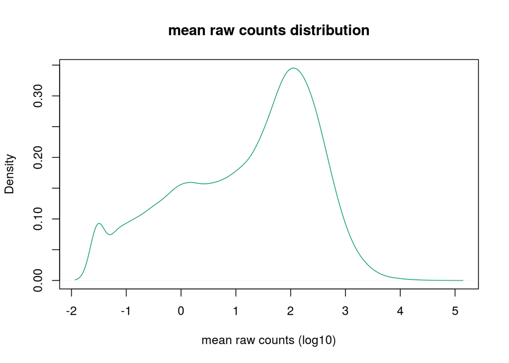

```r
plot(density(log10(rowMeans(count.table))),col=pal[1],
main="mean raw counts distribution",
xlab="mean raw counts (log10)")
```

plot the expression density of every sample

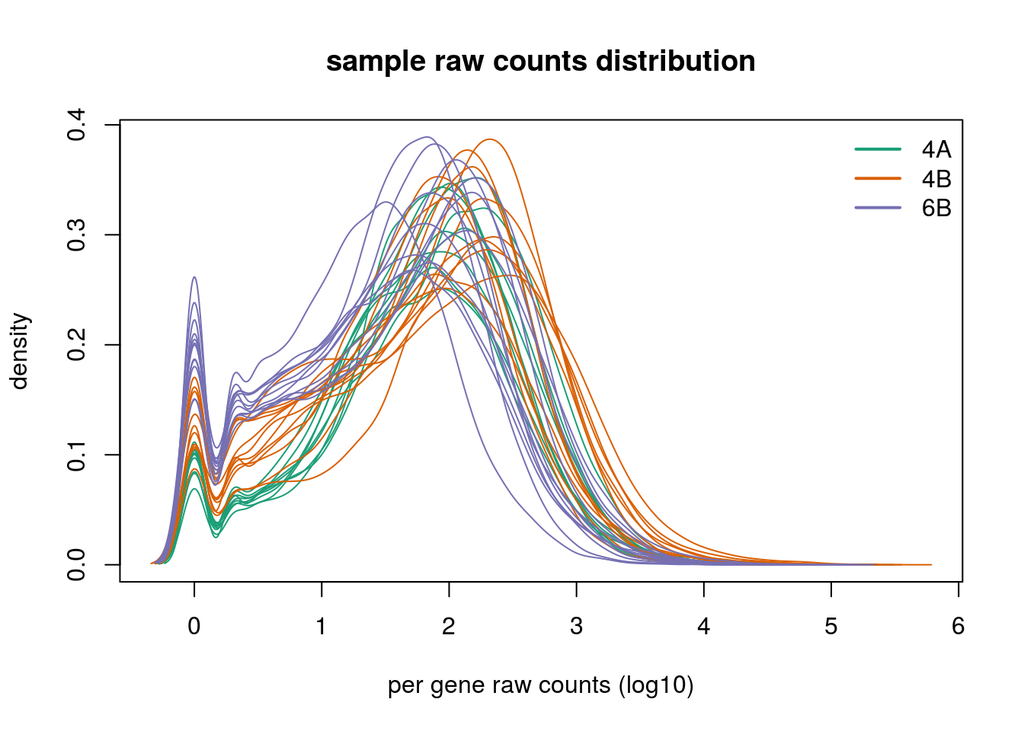

```r
plot.multidensity(log10(count.table),
col=pal[as.integer(samples$Tree)],
legend.x="topright",
legend=levels(samples$Tree),
legend.col=pal[1:nlevels(samples$Tree)],
legend.lwd=2,
main="sample raw counts distribution",
xlab="per gene raw counts (log10)")
```

## 2.3 Biological QC

```r
dds <- DESeqDataSetFromMatrix(
  countData = count.table,
  colData = data.frame(tree=samples$Tree,
                       fraction=samples$othernames),
  design = ~tree+fraction)
```

### 2.3.1 Library size

```r
dds <- estimateSizeFactors(dds)
sizes <- sizeFactors(dds)
names(sizes) <- colnames(count.table)
pander(sizes)
```

Table continues below

| ERR1361084 | ERR1361085 | ERR1361086 | ERR1361087 | ERR1361088 | ERR1361089 |
| --- | --- | --- | --- | --- | --- |
| 0.8315 | 1.302 | 0.8925 | 1.701 | 1.089 | 1.201 |

Table continues below

| ERR1361090 | ERR1361091 | ERR1361095 | ERR1361098 | ERR1361099 | ERR1361100 |
| --- | --- | --- | --- | --- | --- |
| 0.8711 | 0.6909 | 0.7597 | 1.945 | 0.7691 | 1.279 |

Table continues below

| ERR1361101 | ERR1361102 | ERR1361103 | ERR1361104 | ERR1361105 | ERR1361106 |
| --- | --- | --- | --- | --- | --- |
| 1.319 | 0.8887 | 2.092 | 2.161 | 1.83 | 2.164 |

Table continues below

| ERR1361107 | ERR1361108 | ERR1361109 | ERR1361129 | ERR1361130 | ERR1361131 |
| --- | --- | --- | --- | --- | --- |
| 2.633 | 0.8604 | 0.9861 | 0.5353 | 0.7187 | 1.099 |

Table continues below

| ERR1361114 | ERR1361115 | ERR1361116 | ERR1361117 | ERR1361118 | ERR1361119 |
| --- | --- | --- | --- | --- | --- |
| 1.528 | 0.7245 | 1.341 | 0.2893 | 0.6742 | 1.428 |

| ERR1361120 | ERR1361121 | ERR1361122 |
| --- | --- | --- |
| 0.5549 | 0.5199 | 0.6669 |

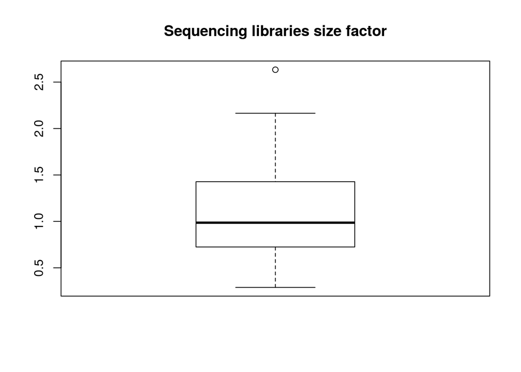

```r
boxplot(sizes, main="Sequencing libraries size factor")
```

### 2.3.2 Estimate the number of expressed genes

```r
vsd <- varianceStabilizingTransformation(dds, blind=TRUE)
vst <- assay(vsd)
vst <- vst - min(vst)
write.csv(vst,"analysis/HTSeq/library-size-normalized_variance-stabilized_PRJEB13583_ctl-selected_frc-data.csv")
```

### 2.3.3 PCA

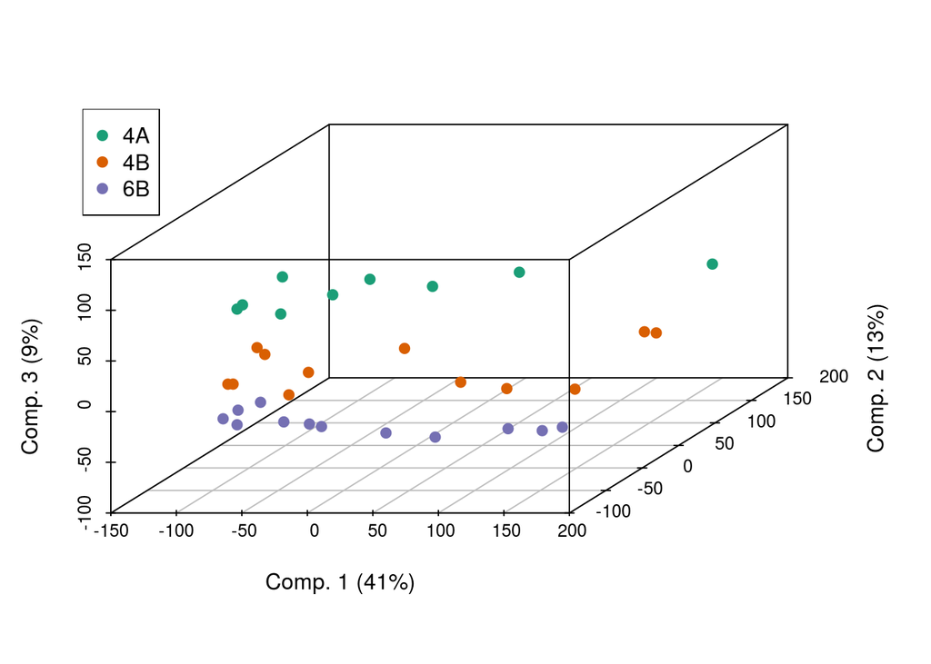

```r
pc <- prcomp(t(vst))
percent <- round(summary(pc)$importance[2,]*100)
mar=c(5.1,4.1,4.1,2.1)
scatterplot3d(pc$x[,1],
pc$x[,2],
pc$x[,3],
xlab=paste("Comp. 1 (",percent[1],"%)",sep=""),
ylab=paste("Comp. 2 (",percent[2],"%)",sep=""),
zlab=paste("Comp. 3 (",percent[3],"%)",sep=""),
color=pal[as.integer(samples$Tree)],
pch=19)

legend("topleft",pch=19,
col=pal[1:nlevels(samples$Tree)],
legend=levels(samples$Tree))
```

```r
par(mar=mar)
```

PC1 and PC2

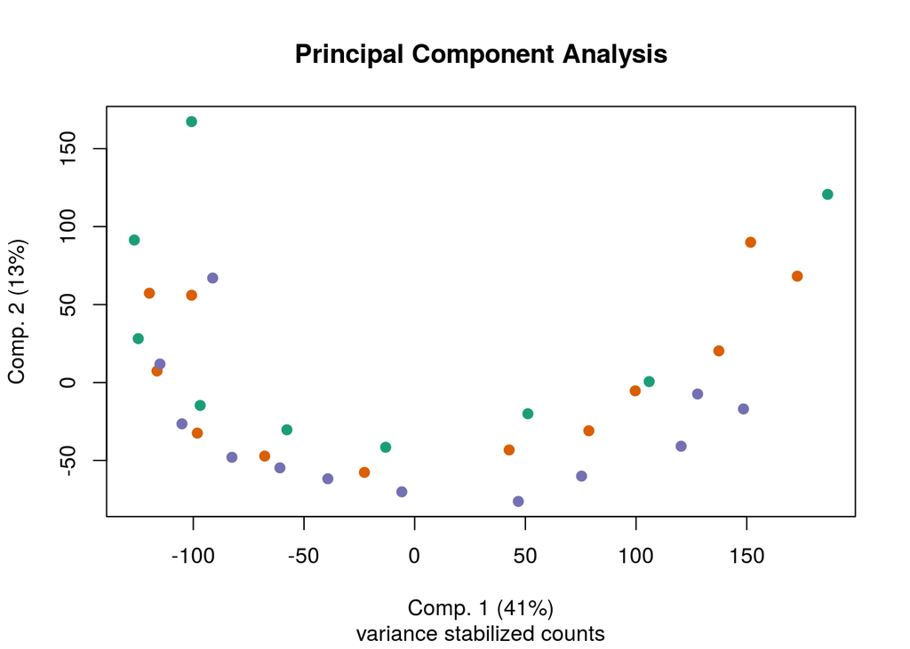

```r
plot(pc$x[,1],
pc$x[,2],
xlab=paste("Comp. 1 (",percent[1],"%)",sep=""),
ylab=paste("Comp. 2 (",percent[2],"%)",sep=""),
col=pal[as.integer(samples$Tree)],
pch=19,
main="Principal Component Analysis",sub="variance stabilized counts")
```

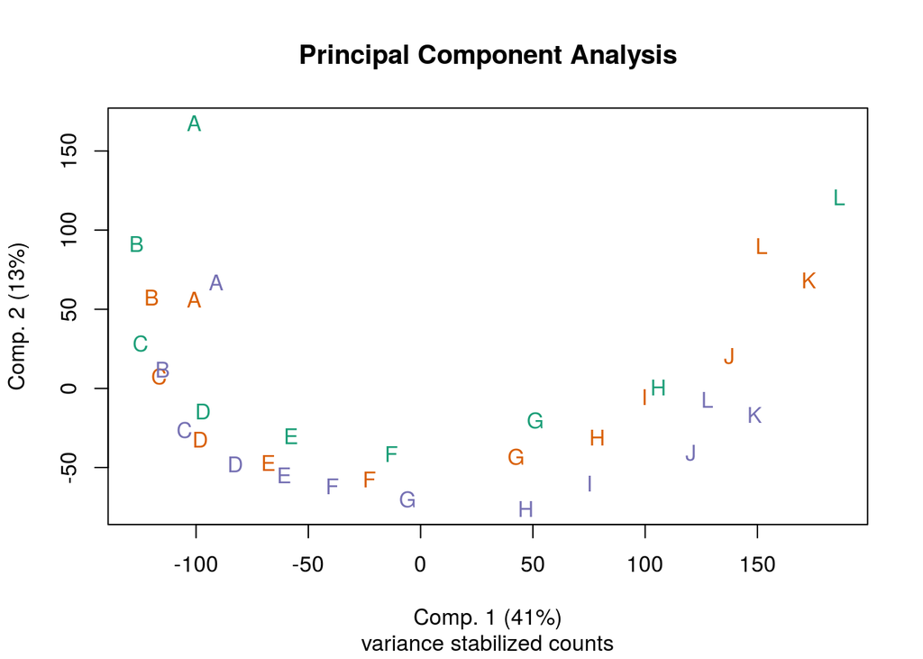

```r
plot(pc$x[,1],
pc$x[,2],
xlab=paste("Comp. 1 (",percent[1],"%)",sep=""),
ylab=paste("Comp. 2 (",percent[2],"%)",sep=""),
col=pal[as.integer(samples$Tree)],
pch=LETTERS[factor(samples$othernames)],
main="Principal Component Analysis",sub="variance stabilized counts")
```

PC2 and PC3

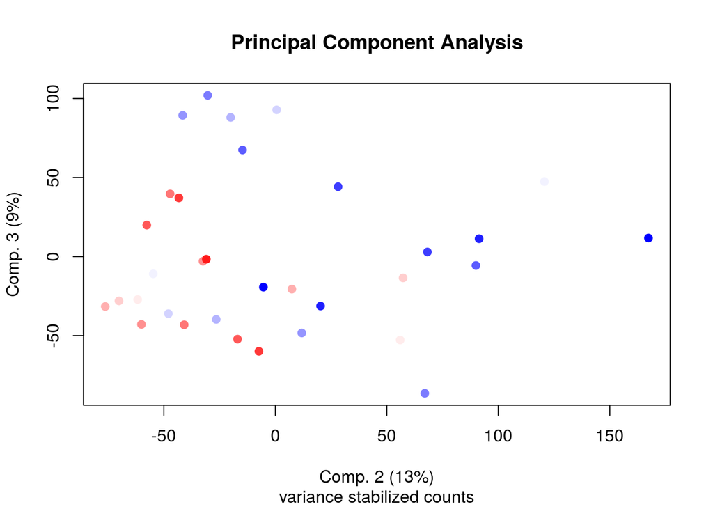

```r
plot(pc$x[,2],
pc$x[,3],
xlab=paste("Comp. 2 (",percent[2],"%)",sep=""),
ylab=paste("Comp. 3 (",percent[3],"%)",sep=""),
col=hpal[round(seq(1,100,100/length(unique(samples$Fraction))))],
pch=19,
main="Principal Component Analysis",sub="variance stabilized counts")
```

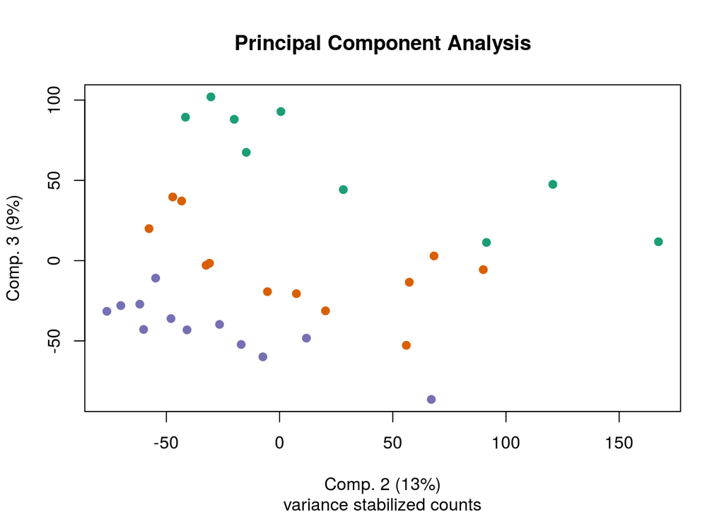

```r
plot(pc$x[,2],
pc$x[,3],
xlab=paste("Comp. 2 (",percent[2],"%)",sep=""),
ylab=paste("Comp. 3 (",percent[3],"%)",sep=""),
col=pal[as.integer(samples$Tree)],
pch=19,
main="Principal Component Analysis",sub="variance stabilized counts")
```

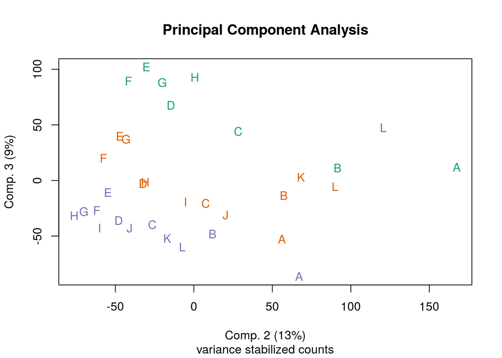

```r
plot(pc$x[,2],
pc$x[,3],
xlab=paste("Comp. 2 (",percent[2],"%)",sep=""),
ylab=paste("Comp. 3 (",percent[3],"%)",sep=""),
col=pal[as.integer(samples$Tree)],
pch=LETTERS[factor(samples$othernames)],
main="Principal Component Analysis",sub="variance stabilized counts")
```

PC1 and PC3

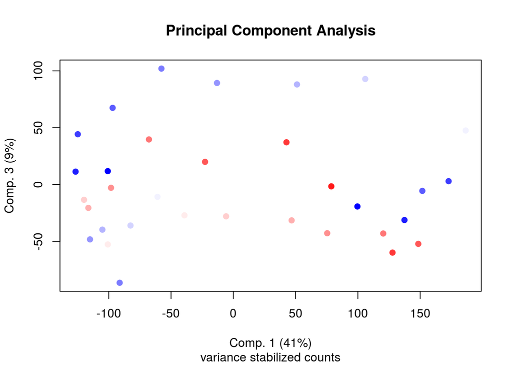

```r
plot(pc$x[,1],
pc$x[,3],
xlab=paste("Comp. 1 (",percent[1],"%)",sep=""),
ylab=paste("Comp. 3 (",percent[3],"%)",sep=""),
col=hpal[round(seq(1,100,100/length(unique(samples$Fraction))))],
pch=19,
main="Principal Component Analysis",sub="variance stabilized counts")
```

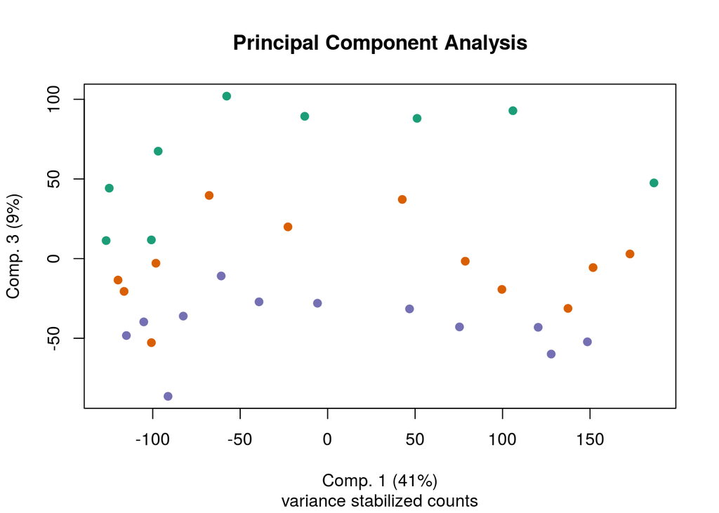

```r
plot(pc$x[,1],
pc$x[,3],
xlab=paste("Comp. 1 (",percent[1],"%)",sep=""),
ylab=paste("Comp. 3 (",percent[3],"%)",sep=""),
col=pal[as.integer(samples$Tree)],
pch=19,
main="Principal Component Analysis",sub="variance stabilized counts")
```

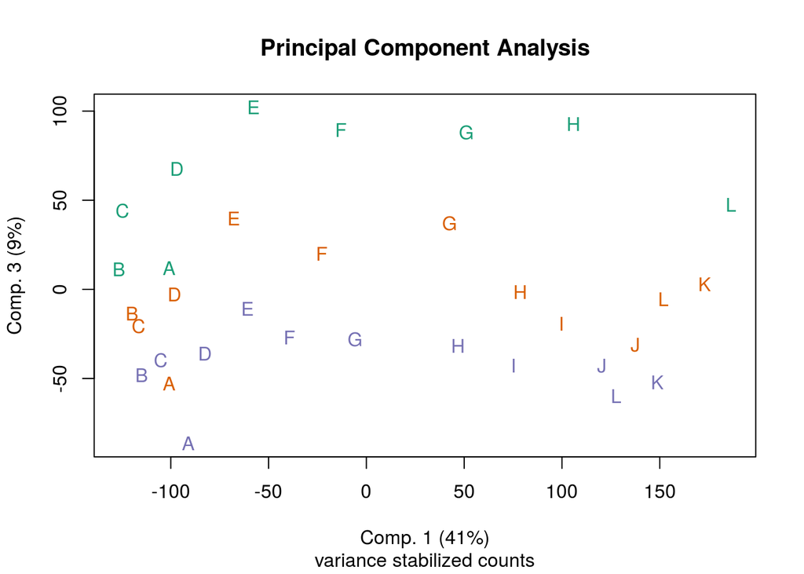

```r
plot(pc$x[,1],
pc$x[,3],
xlab=paste("Comp. 1 (",percent[1],"%)",sep=""),
ylab=paste("Comp. 3 (",percent[3],"%)",sep=""),
col=pal[as.integer(samples$Tree)],
pch=LETTERS[factor(samples$othernames)],
main="Principal Component Analysis",sub="variance stabilized counts")
```

### 2.3.4 Gene selection

```r
sel <- featureSelect(vst,factor(samples$othernames),2)
sprintf("There are %s selected genes",sum(sel))
```

```
## [1] "There are 23228 selected genes"
```

### 2.3.5 Heatmap

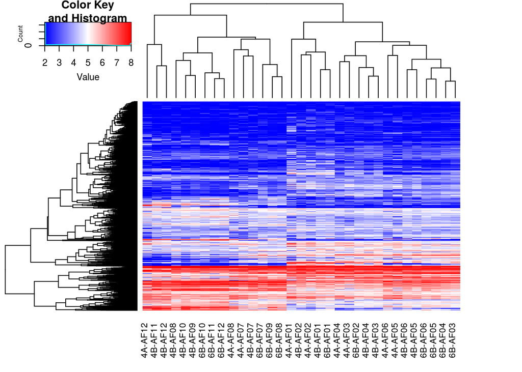

```r
dat.sat <- vst[sel,]
dat.sat[dat.sat < 2 ] <- 2
dat.sat[dat.sat > 8 ] <- 8
heatmap.2(as.matrix(dat.sat),
          labRow=NA,trace="none",
          las=2,col=hpal,
          labCol = paste(samples$Tree,samples$othernames,sep="-"))
```

plot the distribution

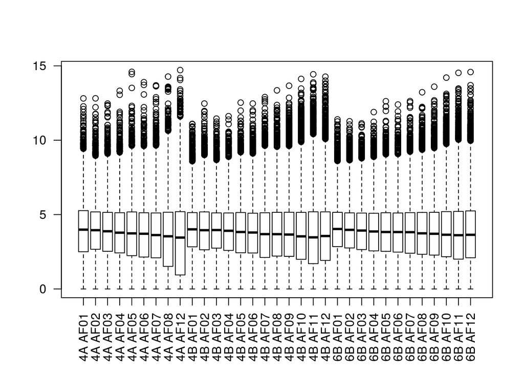

```r
boxplot(vst[sel,],names=paste(samples$Tree,samples$othernames),las=2)
```

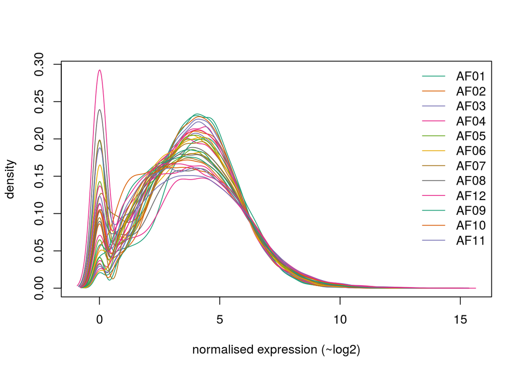

```r
plot.multidensity(lapply(1:ncol(vst),function(i){vst[sel,i]}),
                  col=pal[c(1:8,1:4)][as.integer(factor(samples$othernames))],legend.x = "topright",
                  legend = unique(samples$othernames),
                  xlab="normalised expression (~log2)")
```

Number of genes expressed

```r
tab <- colSums(vst[sel,]>0)
names(tab) <- paste(samples$Tree,samples$othernames)
pander(tab)
```

Table continues below

| 4A AF01 | 4A AF02 | 4A AF03 | 4A AF04 | 4A AF05 | 4A AF06 | 4A AF07 | 4A AF08 |
| --- | --- | --- | --- | --- | --- | --- | --- |
| 20370 | 21895 | 21674 | 21705 | 21134 | 20813 | 20148 | 19227 |

Table continues below

| 4A AF12 | 4B AF01 | 4B AF02 | 4B AF03 | 4B AF04 | 4B AF05 | 4B AF06 | 4B AF07 |
| --- | --- | --- | --- | --- | --- | --- | --- |
| 18024 | 22998 | 22081 | 22880 | 22778 | 22369 | 22640 | 21577 |

Table continues below

| 4B AF08 | 4B AF09 | 4B AF10 | 4B AF11 | 4B AF12 | 6B AF01 | 6B AF02 | 6B AF03 |
| --- | --- | --- | --- | --- | --- | --- | --- |
| 21794 | 22718 | 22565 | 20121 | 21084 | 22731 | 22832 | 22843 |

Table continues below

| 6B AF04 | 6B AF05 | 6B AF06 | 6B AF07 | 6B AF08 | 6B AF09 | 6B AF10 | 6B AF11 |
| --- | --- | --- | --- | --- | --- | --- | --- |
| 22925 | 22698 | 22953 | 21927 | 21951 | 22456 | 21634 | 21287 |

| 6B AF12 |
| --- |
| 22170 |

Number of genes expressed over a cutoff

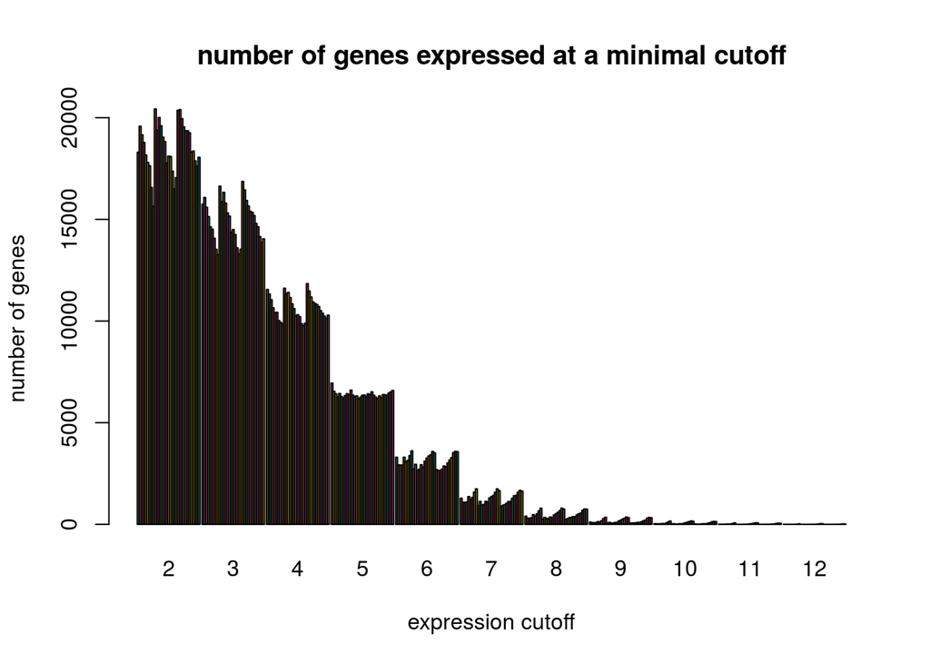

```r
barplot(sapply(2:12,function(ct){
  colSums(vst[sel,] >= ct)
}),beside=TRUE,col=pal[c(1:8,1:4)],xlab ="expression cutoff",
names.arg = 2:12,ylab="number of genes",
main="number of genes expressed at a minimal cutoff")
```

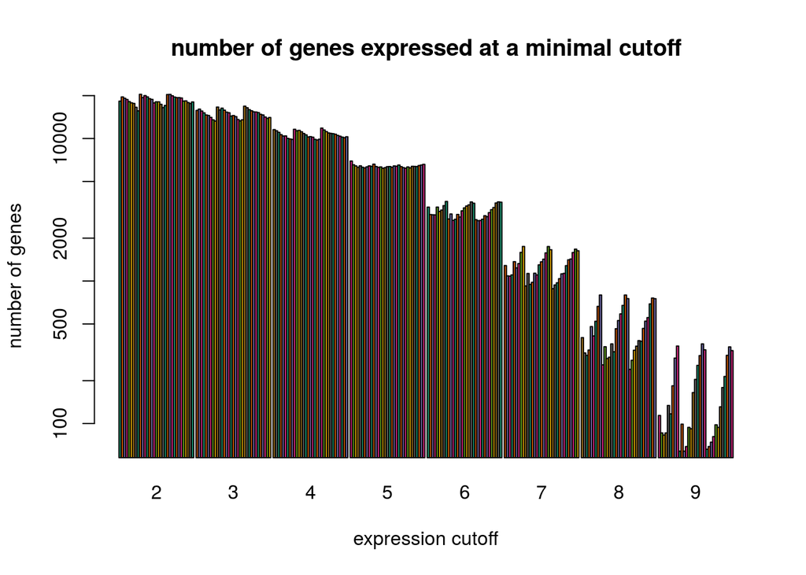

```r
barplot(sapply(2:9,function(ct){
  colSums(vst[sel,] >= ct)
}),beside=TRUE,col=pal[c(1:8,1:4)],xlab ="expression cutoff",names.arg = 2:9,
log="y",ylab="number of genes",
main="number of genes expressed at a minimal cutoff")
```

Number of genes accounting for a proportion of expression

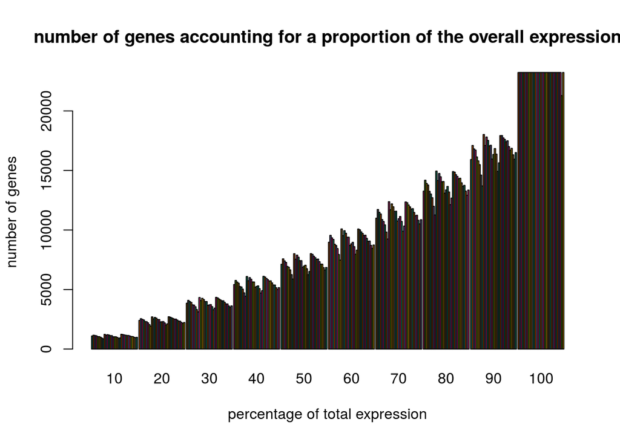

```r
barplot(sapply(seq(0.1,1,0.1),function(ct,mat){
  colSums(mat <= ct)
},t(t(apply(apply(vst[sel,],2,sort,decreasing=TRUE),2,cumsum))/colSums(vst[sel,]))),
beside=TRUE,col=pal[c(1:8,1:4)],xlab ="percentage of total expression",
names.arg = seq(10,100,10),ylab="number of genes",
main="number of genes accounting for a proportion of the overall expression")
```

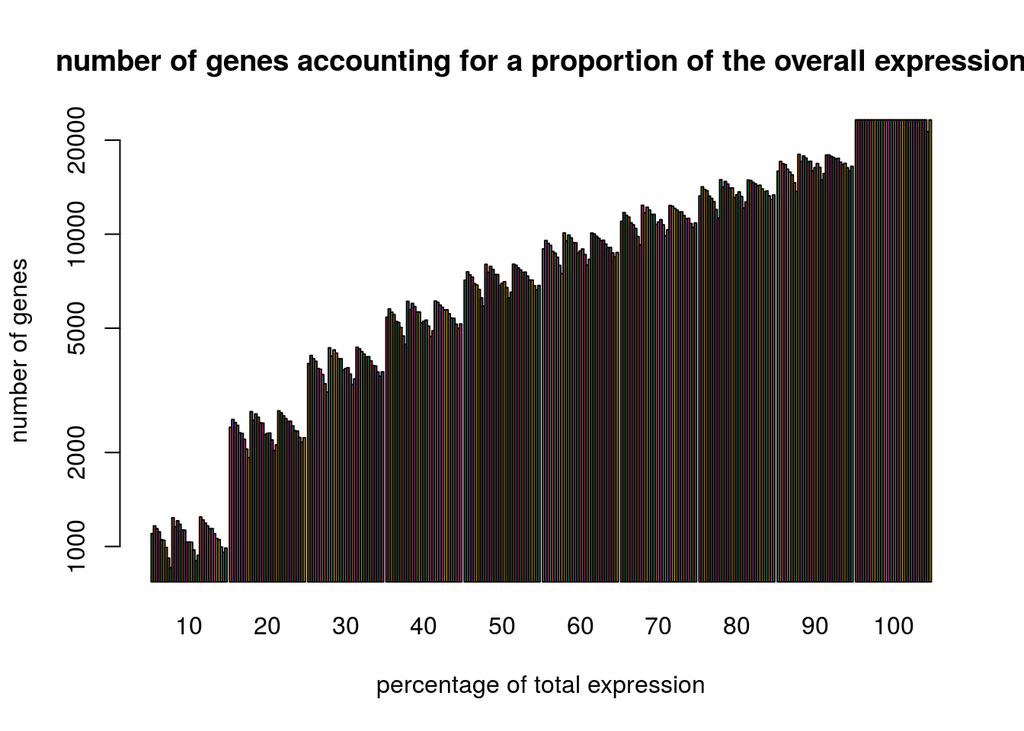

```r
barplot(sapply(seq(0.1,1,0.1),function(ct,mat){
  colSums(mat <= ct)
},t(t(apply(apply(vst[sel,],2,sort,decreasing=TRUE),2,cumsum))/colSums(vst[sel,]))),
beside=TRUE,col=pal[c(1:8,1:4)],xlab ="percentage of total expression",
names.arg = seq(10,100,10),ylab="number of genes",log="y",
main="number of genes accounting for a proportion of the overall expression")
```

Fraction of genes in the different bins

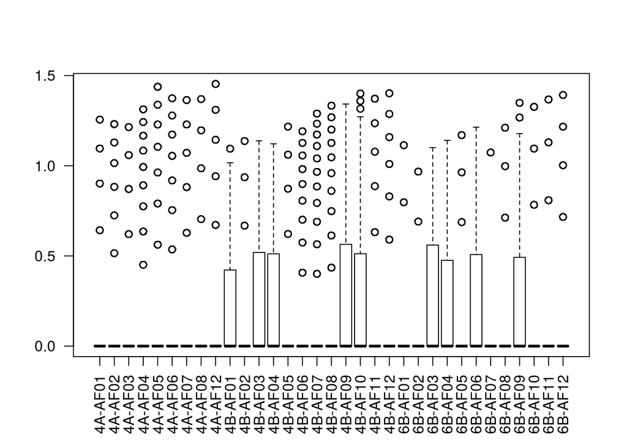

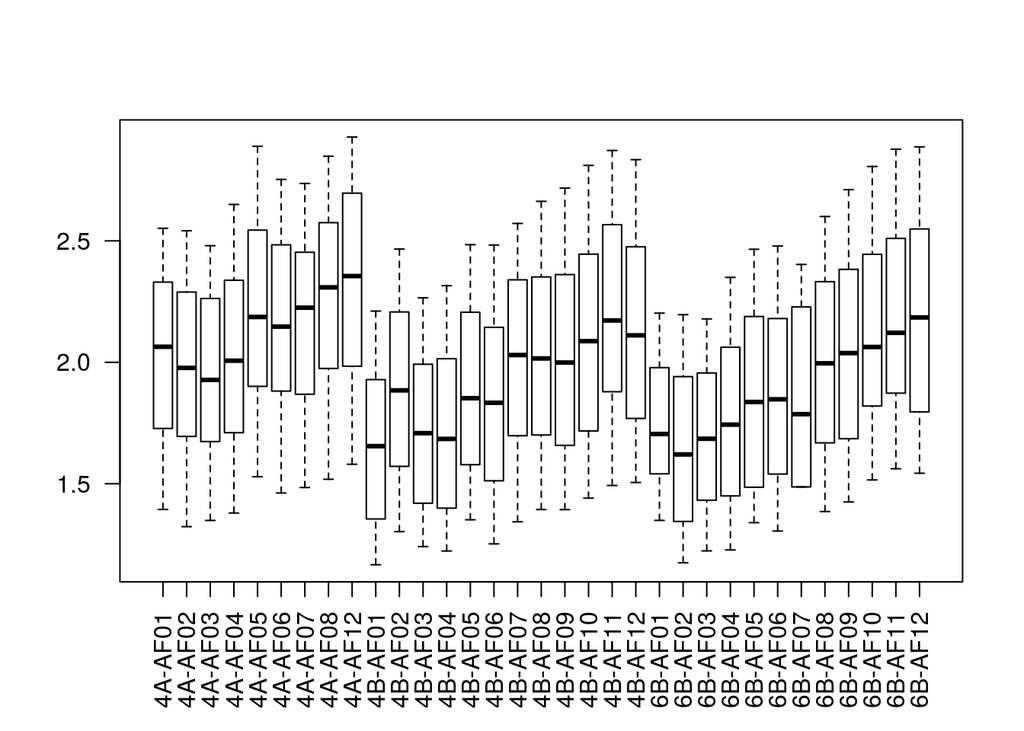

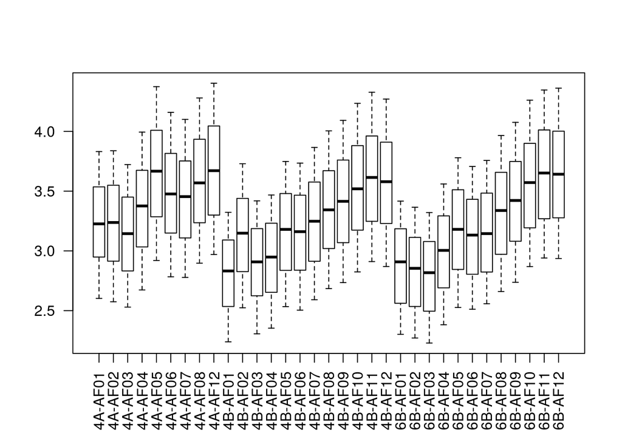

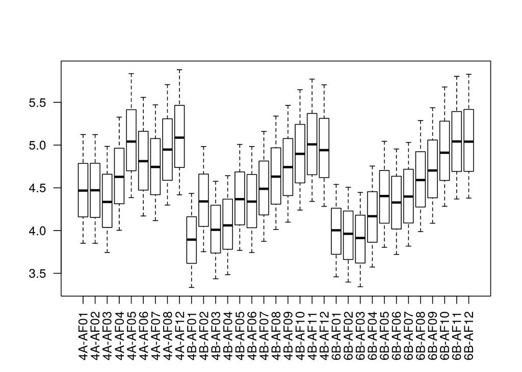

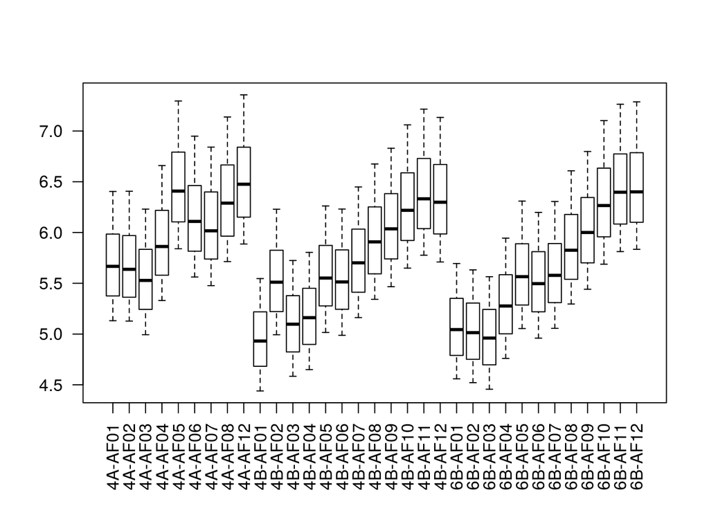

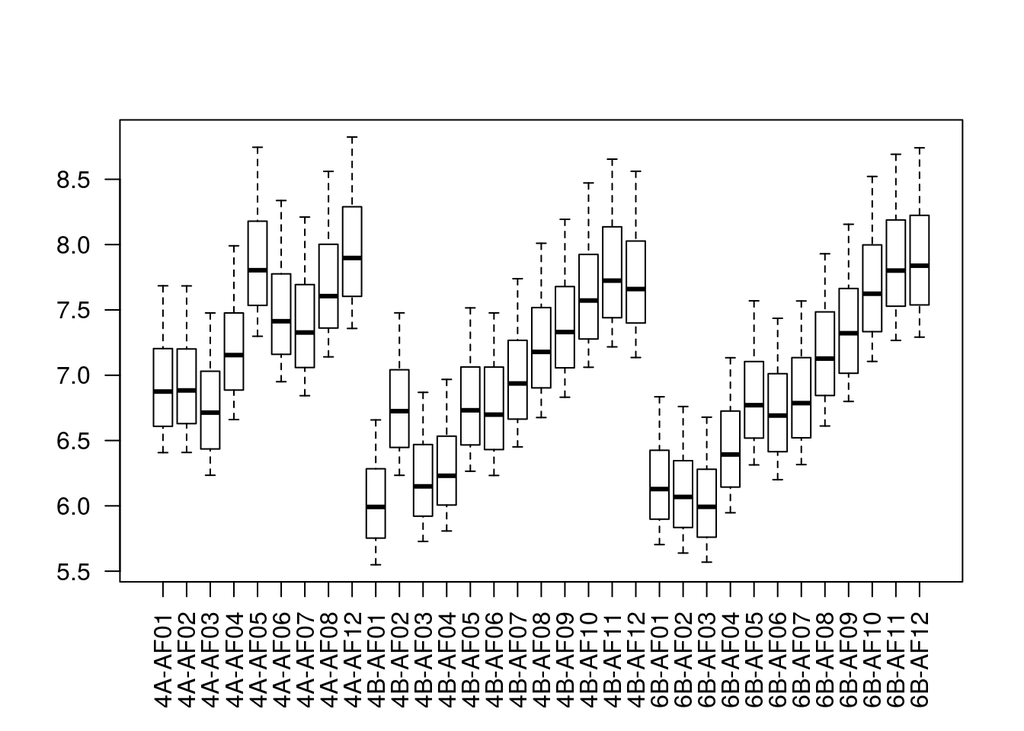

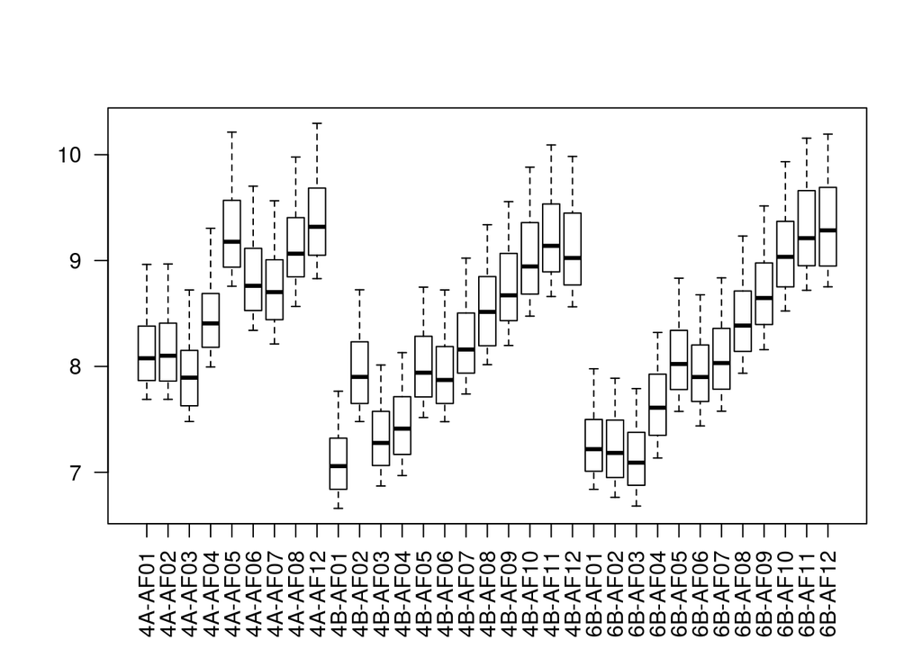

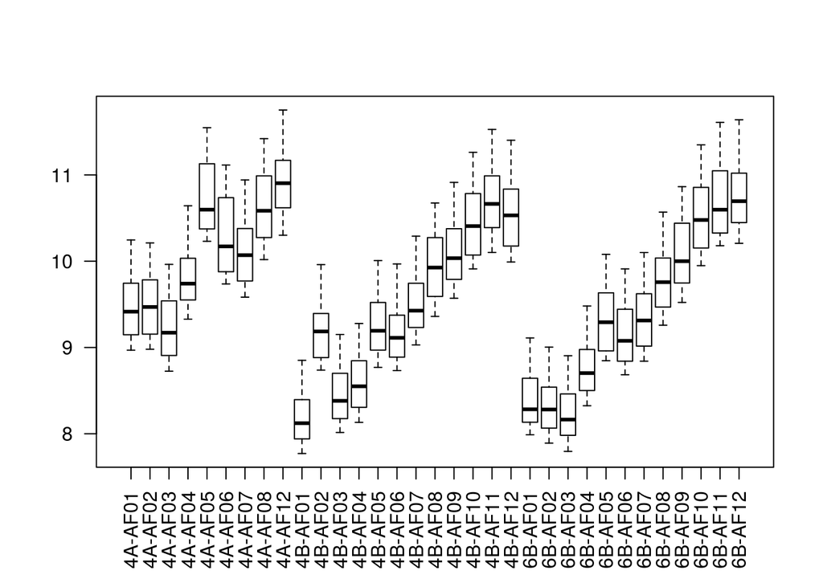

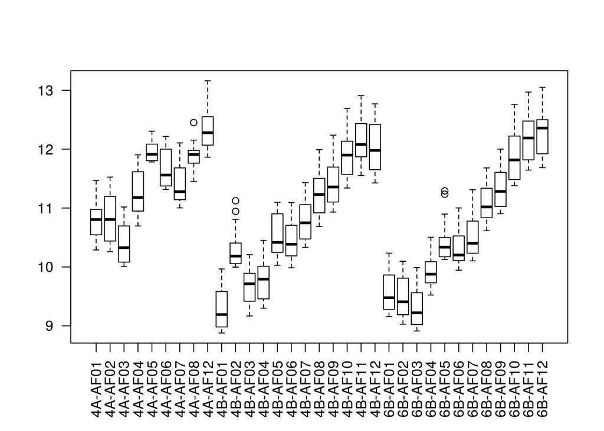

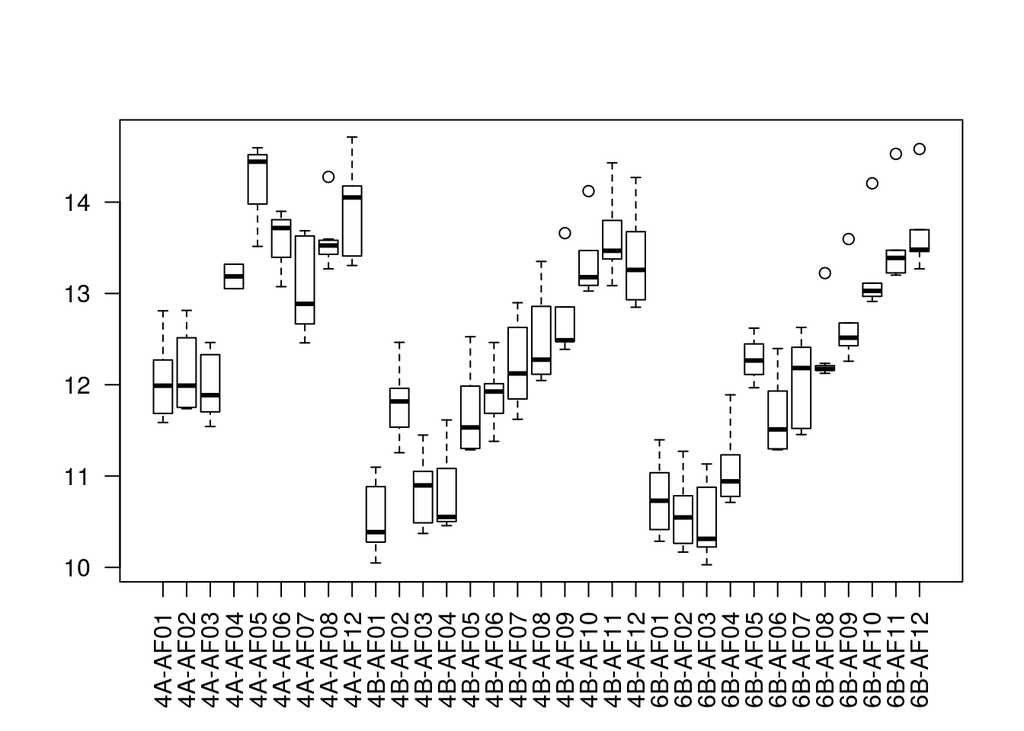

```r
v <- apply(vst,2,function(co){split(co,cut(co,10))})

dev.null <- sapply(1:10,function(i){
  boxplot(lapply(v,"[[",i),las=2,names=paste(samples$Tree,samples$othernames,sep="-"))}
)
```

# 3 Conclusion

The data quality looks better now, however there is an effect of the sequencing depth that becomes shallower as samples got from the phloem to the xylem. This resulted in less genes having their expression recorded as the samples went inwood. This effect was “counterbalanced” by the library size estimation, resulting in a technical increase of the average gene expression values for many genes as samples were going inwards the wood. This needs to be corrected for, if possible, as it will be confounded with real biological changes.